# Biopsies sample grouping (PCA, age clusters)

Geremy Clair

May 4, 2020

# 1 Data loading and cleaning

Load the necessary libraries

```r
#load reshape for melting tables
library(FactoMineR)
library(ggplot2)
library(ggfortify)
library(viridis)
library(cluster)
library(factoextra)
```

The data contained in the file “protein abundances.csv” and its corresponding metadata (“metadata.csv”) were loaded in the R environment.

```r
#load the data
proteins <-read.csv("Protein abundances.csv")
rownames(proteins)<- proteins[,1]
proteins<-proteins[,2:ncol(proteins)]

#load the metadata
metadata <- read.csv("metadata.csv")
rownames(metadata)<-metadata[,1]
metadata<-data.frame(t(metadata[,2:ncol(metadata)]))
```

The rows containing missing values were removed

```r
paste0(sum(rowSums(is.na(proteins))>0)," rows were containing missing values and were removed.")
```

```
## [1] "3 rows were containing missing values and were removed."
```

```r
proteins<-proteins[rowSums(is.na(proteins))==0,]
```

# 2 PCA

The PCA was performed using the function PCA() from FactoMineR.

```r
PCA_results<-PCA(t(proteins),graph =F)
PCA_coord<-data.frame(PCA_results$ind$coord)
age_in_days<-as.numeric(as.character(metadata$age_in_days))
logAge<-log10(age_in_days)
PCA_coord<-data.frame(cbind(PCA_coord,age_in_days=age_in_days,log_age=logAge))
```

The individual coordinates were plotted

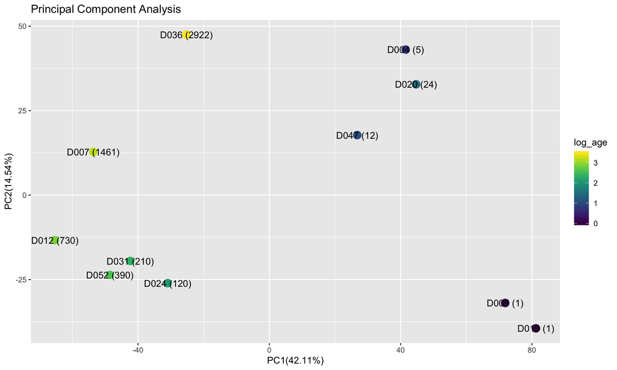

```r
ggplot(PCA_coord,aes(x=Dim.1,y=Dim.2)) +
  geom_point(size=4,aes(colour=log_age))+
  scale_color_viridis()+
  geom_text(aes(label=paste0(rownames(PCA_coord)," (",PCA_coord$age_in_days,")")))+
  ggtitle("Principal Component Analysis") +
  xlab(paste0("PC1(",round(PCA_results$eig[,2][1],2),"%)"))+
  ylab(paste0("PC2(",round(PCA_results$eig[,2][2],2),"%)"))
```

# 3 Grouping evaluation

Two main groups by age separated by the component 1 were clearly distinct here. Each group presented two sub age groups separated by the second component

## 3.1 main grouping

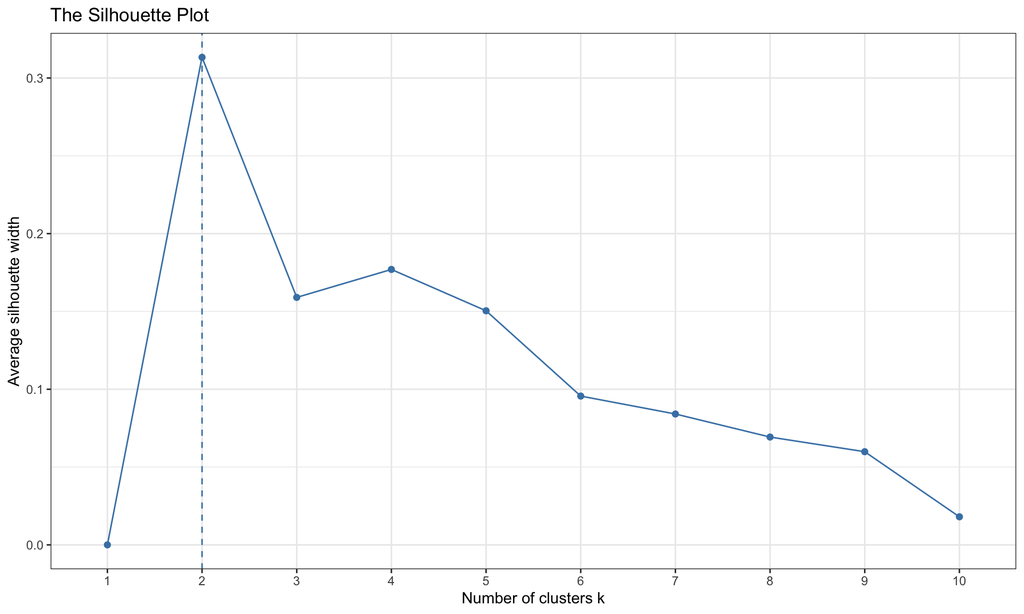

```r
fviz_nbclust(t(proteins), kmeans, method = "silhouette", k.max = 10) + theme_bw() + ggtitle("The Silhouette Plot")
```

2 main clusters were found, the K-means groups were determined for these two clusters

```r
k<-kmeans(t(proteins),2)
print("the clusters were the following")
```

```
## [1] "the clusters were the following"
```

```r
print(k$cluster)
```

```
## D005 D019 D004 D047 D020 D024 D031 D052 D012 D007 D036
##    1    1    1    1    1    2    2    2    2    2    2
```

The clusters were used to color the PCA plot

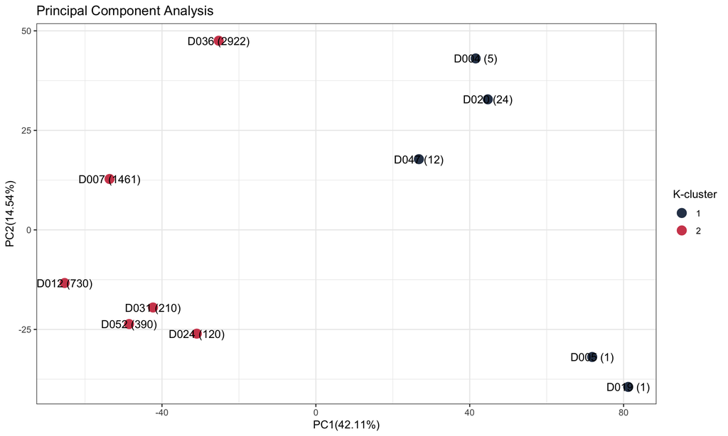

```r
#pdf("PCA_plot.pdf", height = 5, width = 6,useDingbats=FALSE)
ggplot(PCA_coord,aes(x=Dim.1,y=Dim.2)) +
  geom_point(size=4,aes(colour=as.factor(k$cluster)))+
  scale_color_manual(values=c("#2e4057","#d1495b"),name="K-cluster")+
  geom_text(aes(label=paste0(rownames(PCA_coord)," (",PCA_coord$age_in_days,")")))+
  ggtitle("Principal Component Analysis") +
  xlab(paste0("PC1(",round(PCA_results$eig[,2][1],2),"%)"))+
  ylab(paste0("PC2(",round(PCA_results$eig[,2][2],2),"%)"))+
  theme_bw()
```

```r
#dev.off()
```

## 3.2 Sub-grouping

In order to identify it the subgroup were validated by the same method we subsetted the whole table into two tables corresponding to the two subgroups

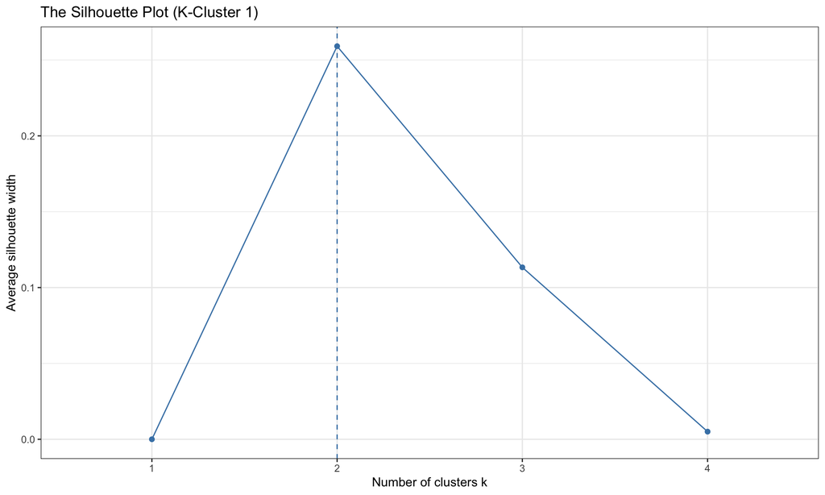

```r
#create the first subset for K-Cluster 1
proteins_1<-proteins[,k$cluster==1]

#Evaluate the best number of clusters using the silouhette method
fviz_nbclust(t(proteins_1), kmeans, method = "silhouette", k.max = 4) + theme_bw() + ggtitle("The Silhouette Plot (K-Cluster 1)")
```

```r
#Calculate the sub-clusters
k1<-kmeans(t(proteins_1),2)

#print the results
print("The best K-subClusters for protein_1 were the following")
```

```
## [1] "The best K-subClusters for protein_1 were the following"
```

```r
print(k1$cluster)
```

```
## D005 D019 D004 D047 D020
##    2    2    1    1    1
```

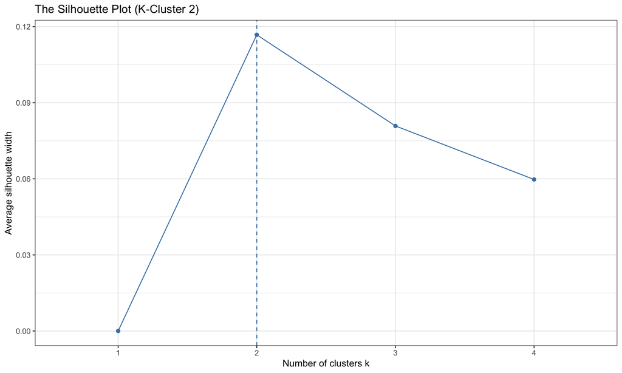

```r
#create the second subset for K-Cluster 2
proteins_2<-proteins[,k$cluster==2]

#Evaluate the best number of clusters using the silouhette method
fviz_nbclust(t(proteins_2), kmeans, method = "silhouette", k.max = 4) + theme_bw() + ggtitle("The Silhouette Plot (K-Cluster 2)")
```

```r
#Calculate the sub-clusters
k2<-kmeans(t(proteins_2),2)

#print the results
print("The best K-subClusters for protein_2 were the following")
```

```
## [1] "The best K-subClusters for protein_2 were the following"
```

```r
print(k2$cluster)
```

```
## D024 D031 D052 D012 D007 D036
##    1    1    1    1    2    2
```

The PCA plot showing these 2 main and their 2 subclusters was plotted

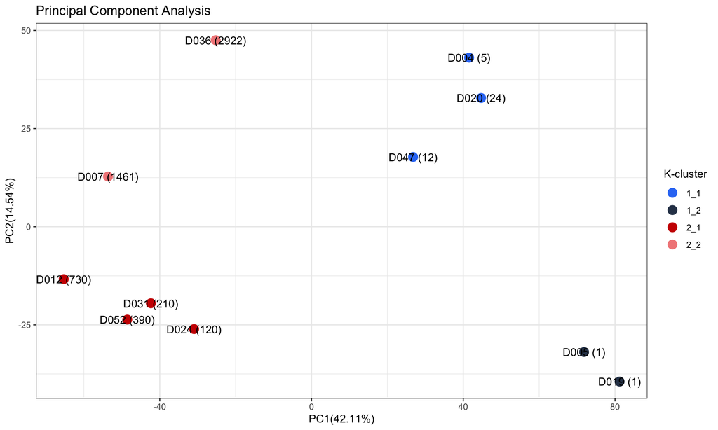

```r
#a cluster and sub_cluster table was created
k_clust<-data.frame(main_clusters=k$cluster)
sc_1<-k1$cluster
sc_2<-k2$cluster
sub_cluster<-c(sc_1,sc_2)
sub_cluster<-sub_cluster[match(names(sub_cluster),rownames(k_clust))]
k_clust<-cbind(k_clust,sub_cluster=sub_cluster)
clusters<-paste0(k_clust$main_clusters,"_",k_clust$sub_cluster)
k_clust<-cbind(k_clust,clusters=clusters)

#and the results were used to color the PCA
#pdf("PCA_plot.pdf", height = 5, width = 6,useDingbats=FALSE)
ggplot(PCA_coord,aes(x=Dim.1,y=Dim.2)) +
  geom_point(size=4,aes(colour=as.factor(k_clust$clusters)))+
  scale_color_manual(values=c("#317bf4","#2e4057","#cc0000","#f28888"),name="K-cluster")+
  geom_text(aes(label=paste0(rownames(PCA_coord)," (",PCA_coord$age_in_days,")")))+
  ggtitle("Principal Component Analysis") +
  xlab(paste0("PC1(",round(PCA_results$eig[,2][1],2),"%)"))+
  ylab(paste0("PC2(",round(PCA_results$eig[,2][2],2),"%)"))+
  theme_bw()
```

```r
#dev.off()
```

```r
#let's extract the contributions from the PCA Results
PC_contrib<-data.frame(PCA_results$var$contrib)
PC1_contrib<-data.frame(PC_contrib$Dim.1)
PC2_contrib<-data.frame(PC_contrib$Dim.2)
rownames(PC1_contrib)<-rownames(PC2_contrib)<-rownames(PC_contrib)
```

Now we will extract the percentage of contribution of the proteins quantified to PC1 and PC2 and plot the distribution of the contributions

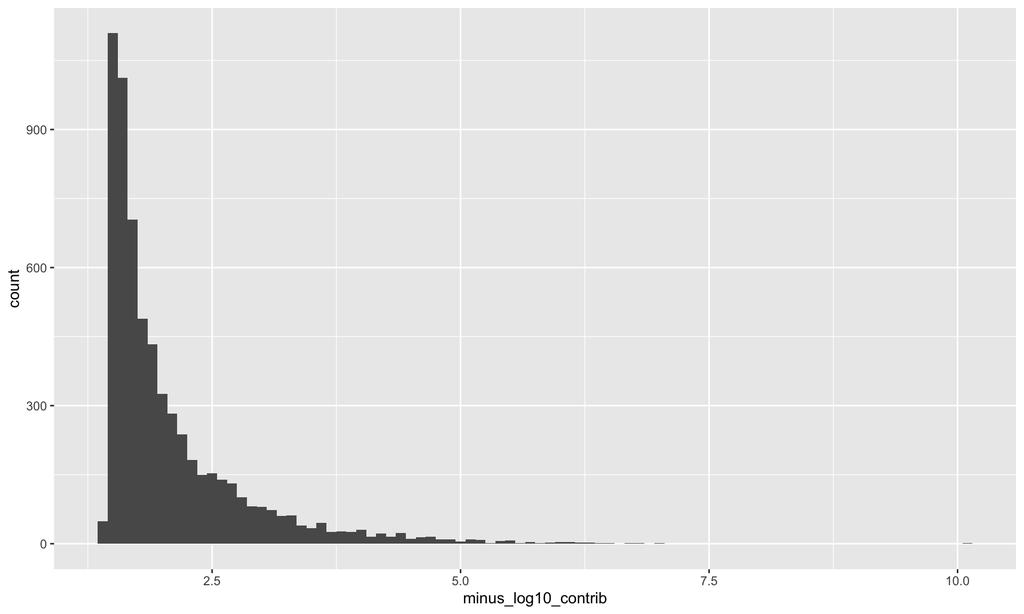

```r
#the -log10 of the PCA contributions were calculated for visualization purposes
PC1_contrib$'minus_log10_contrib'<--log10(PC1_contrib$PC_contrib.Dim.1)
PC2_contrib$'minus_log10_contrib'<--log10(PC2_contrib$PC_contrib.Dim.2)

#plot the distribution of the log transformed contributions
ggplot(PC1_contrib,aes(minus_log10_contrib))+ geom_histogram(binwidth = 0.1)
```

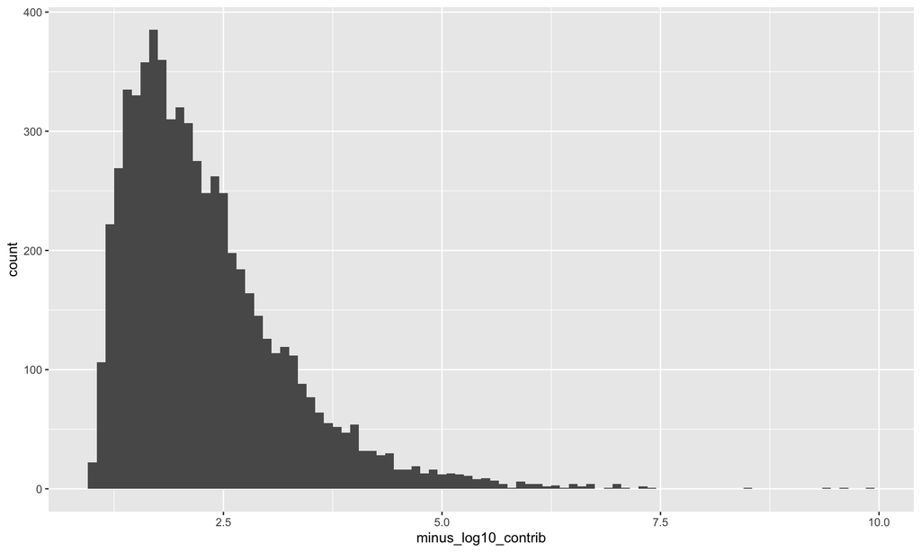

```r
ggplot(PC2_contrib,aes(minus_log10_contrib))+ geom_histogram(binwidth = 0.1)
```

```r
#extract the list of top 500 proteins contributing the most to component 1 and 2
PC1_contrib<- PC1_contrib[order(PC1_contrib$minus_log10_contrib),]
PC2_contrib<- PC2_contrib[order(PC2_contrib$minus_log10_contrib),]
```

# 4 Version R and of the packages used

```r
print(paste0("R version ", version$major,".",version$minor, " was used for this analysis."))
```

```
## [1] "R version 3.6.2 was used for this analysis."
```

```r
packages<-data.frame(installed.packages())
loaded<-as.character(.packages())
print("Below is the version of the packages used for this analysis.")
```

```
## [1] "Below is the version of the packages used for this analysis."
```

```r
print(packages[packages$Package %in% loaded,c(1,3)])
```

```
##                 Package Version
## factoextra   factoextra   1.0.6
## FactoMineR   FactoMineR     2.0
## ggfortify     ggfortify   0.4.8
## ggplot2         ggplot2   3.2.1
## viridis         viridis   0.5.1
## viridisLite viridisLite   0.3.0
## base               base   3.6.2
## cluster         cluster   2.1.0
## datasets       datasets   3.6.2
## graphics       graphics   3.6.2
## grDevices     grDevices   3.6.2
## methods         methods   3.6.2
## stats             stats   3.6.2
## utils             utils   3.6.2
```